# act_report

## Insights

First, we generate a correlation matrix to show relationships between variables.It is possible to see a strong correlation between the favorite_count and retweet_cout variables, so we decided to generate a scatterplot next to observe the behavior of these variables.

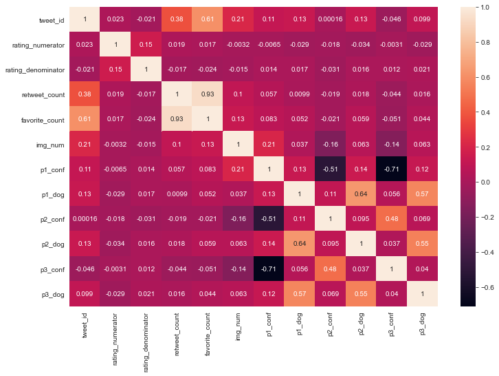

As we can see, in the scatterplot below, as favorites increase, retweets also increase, that means a strong positive relationship

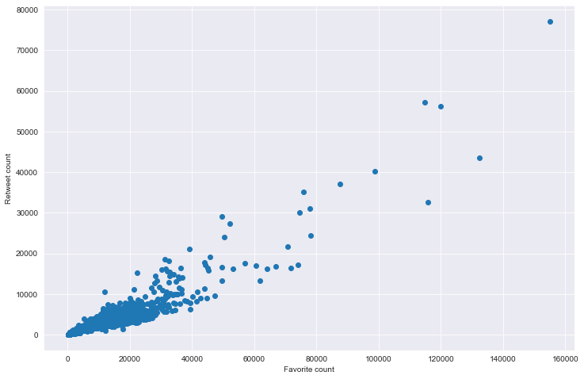

I was curious to get an overview of how people name their dogs. In this dataframe, we have the names Charlie, Cooper and Oliver as the most common.

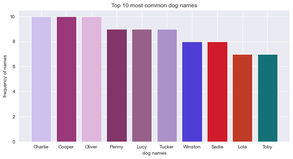

The dog stages also caught my attention, even because it contains many records with the type 'None'. Apart from these cases, the "pupper" stage was the most frequent, as can be seen in the graph below.

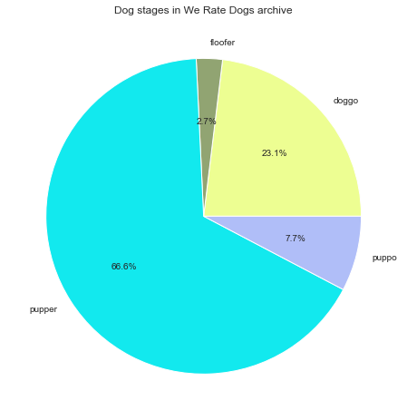

A "pupper", that according to Dogtionary is:

1. A small doggo, usually younger. Can be equally, if not more mature than some doggos;
2. A doggo that is inexperiented, unfamiliar, or in any way unprepared for the responsabilities associated with being a doggo.

More in: [#WeRateDogs book](https://www.amazon.com/WeRateDogs-Most-Hilarious-Adorable-Youve/dp/1510717145)

From there, I decided to go deeper into the analysis of the most common stage, taking the photo of the dog with more favorites and more retweets as well as its breed, to then make a word cloud, considering the entire dataframe.

As much as you have a lovely puppy in the same image, the model recognize only the french bulldog, but it'ok, because they're Good Dogs Brent! =D

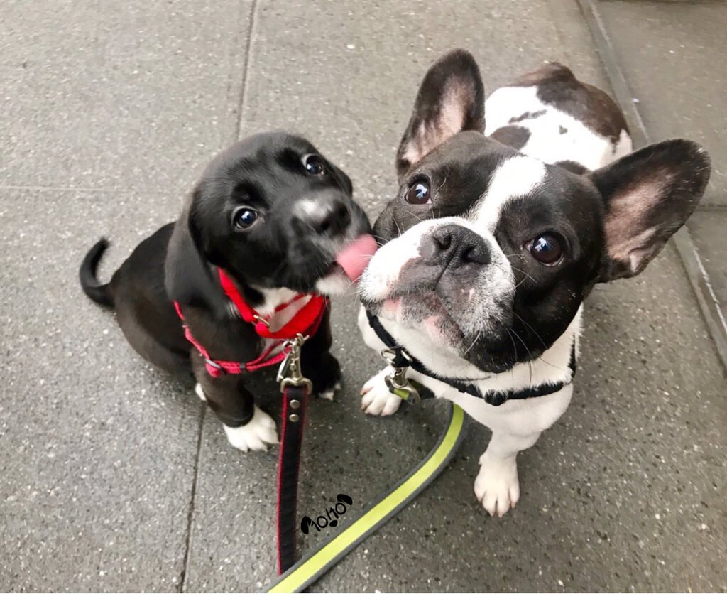

[figure not shown]

Let's see Brent! The word cloud says: (all for me) but in this case, pupper french bulldogs are good dogs!